# ECE 5470 Lab 7 Report

## by Junjie Tian

```python
#Importing required libraries

from v4 import vx
from v4 import vd
from scipy.ndimage import center_of_mass
from scipy.ndimage import shift
from PIL import Image
import matplotlib.pyplot as plt

import numpy as np
import pandas as pd
import sklearn
import matplotlib as mpl
import matplotlib.pyplot as plt
from sklearn.preprocessing import StandardScaler
from sklearn.neighbors import KNeighborsClassifier
from sklearn.decomposition import PCA
from sklearn.neural_network import MLPClassifier
from sklearn.svm import SVC
from sklearn.linear_model import SGDClassifier
from sklearn.metrics import precision_recall_fscore_support
from sklearn.metrics import accuracy_score
import time
```

## Part A Section 1

```python
# Change the input image from 3 color channels to binary. (1 channel)
for i in range(60):
    image = Image.open(f"./original/img{i}.jpg")
    grayscale_image = image.convert('L')
    grayscale_image.save(f'./gray_input/img{i}.png')
```

```python
for i in range(60):
    # Load the image and apply threshold
    exec(vx.vxsh(f'vpix th=100 if=./gray_input/img{i}.png of=tst{i}_th.vx'))

    # Determine rescaling factors based on bounding box size
    size_im = vx.Vx(f'tst{i}_th.vx')
    rescale_x = 1.0 / (size_im.i.shape[1] / 20)
    rescale_y = 1.0 / (size_im.i.shape[0] / 20)

    # Apply the rescaling to the image
    exec(vx.vxsh(f'vmag m={rescale_x},{rescale_y} if=tst{i}_th.vx of=./th20_out/img{i}_20.vx'))

    # Threshold again, negate all values to make foreground light and background dark
    exec(vx.vxsh(f'vpix th=200 if=./th20_out/img{i}_20.vx of=./th20_bi/img{i}_bi.vx -neg'))
```

```python
# Calculate the COM and translate to size 28 * 28
for i in range(60):
    imagei = vx.Vx(f'./th20_bi/img{i}_bi.vx')
    im = imagei.i
    com_y, com_x = center_of_mass(im)

    s = 28
    tm = np.zeros((s,s), dtype='uint8')
    target_size = 28
    center_y, center_x = target_size // 2, target_size // 2

    # Calculate transition
    x_move = 14 - com_x
    y_move = 14 - com_y

    # Translate
    for y in range(im.shape[0]):
        for x in range(im.shape[1]):
            new_y = int(y + y_move)
            new_x = int(x + x_move)
            if 0 <= new_y and new_y < s and 0 <= new_x and new_x < s:
                tm[new_y][new_x] = im[y][x]

    tmimage = vx.Vx()
    tmimage.i = tm.astype('uint8')
    tmimage.write(f'./idata/img{i}_28.png')
```

```python
# Use vmorph to make the lines thicker
for i in range(60):
    exec(vx.vxsh(f'vmorph if=./idata/img{i}_28.png of=./idata2/img{i}_t.vx t=s s=2 -d'))
    exec(vx.vxsh(f'vxport if=./idata2/img{i}_t.vx of=./idata2/img{i}_t.png -png'))
```

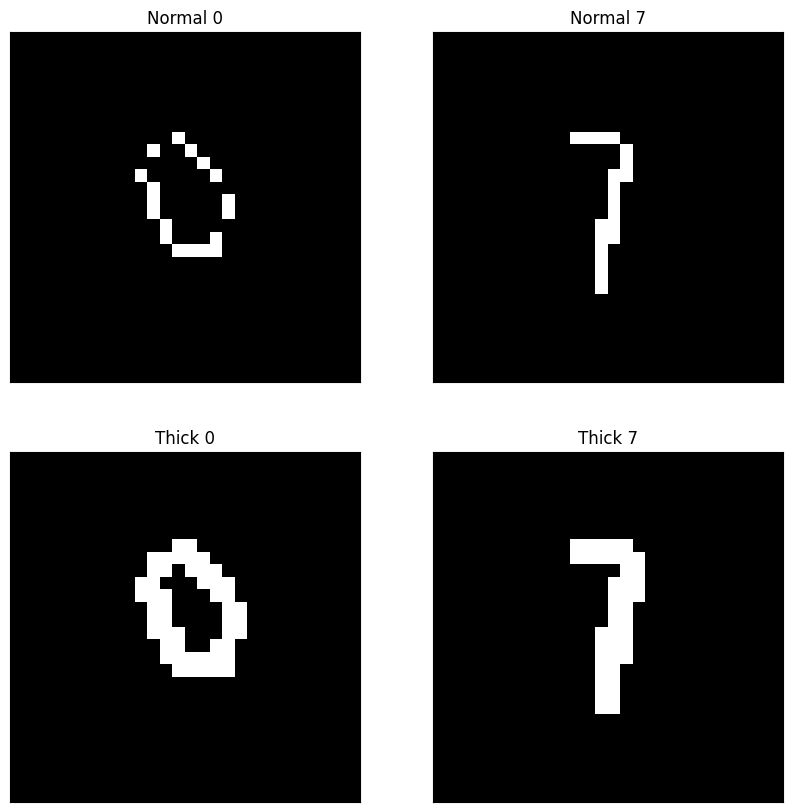

```python
# Display some image examples
im1 = plt.imread('./idata/img0_28.png')
im2 = plt.imread('./idata/img35_28.png')
im3 = plt.imread('./idata2/img0_t.png')
im4 = plt.imread('./idata2/img35_t.png')

plt.figure(figsize=(10, 10))

plt.subplot(2, 2, 1)  # 2 rows, 2 columns, position 1
plt.imshow(im1, interpolation='nearest', cmap=plt.cm.gray)
plt.xticks([])  # Hide x ticks
plt.yticks([])  # Hide y ticks
plt.title('Normal 0')

plt.subplot(2, 2, 2)  # 2 rows, 2 columns, position 2
plt.imshow(im2, interpolation='nearest', cmap=plt.cm.gray)
plt.xticks([])  # Hide x ticks
plt.yticks([])  # Hide y ticks
plt.title('Normal 7')

plt.subplot(2, 2, 3)  # 2 rows, 2 columns, position 3
plt.imshow(im3, interpolation='nearest', cmap=plt.cm.gray)
plt.xticks([])  # Hide x ticks
plt.yticks([])  # Hide y ticks
plt.title('Thick 0')

plt.subplot(2, 2, 4)  # 2 rows, 2 columns, position 4
plt.imshow(im4, interpolation='nearest', cmap=plt.cm.gray)
plt.xticks([])  # Hide x ticks
plt.yticks([])  # Hide y ticks
plt.title('Thick 7')
```

Discussion: The thicker numbers are thicker than the original numbers. The steps are shown above.

## Part A, Section 2

```python
#1 import required modules
import time
import io
import matplotlib.pyplot as plt
import numpy as np
from scipy.io.arff import loadarff

from sklearn.datasets import get_data_home
from joblib import Memory
from sklearn.linear_model import LogisticRegression
from sklearn.model_selection import train_test_split
from sklearn.preprocessing import StandardScaler
from sklearn.utils import check_random_state
from urllib.request import urlopen
```

```python
#2.  read the NMIST dataset
memory = Memory(get_data_home())
@memory.cache()
def fetch_mnist():
    content = urlopen(
        'https://www.openml.org/data/download/52667/mnist_784.arff').read()
    data, meta = loadarff(io.StringIO(content.decode('utf8')))
    data = data.view([('pixels', '<f8', 784), ('class', '|S1')])
    return data['pixels'], data['class']
X, y = fetch_mnist()
```

```python
# rescale the data, use the traditional train/test split

X = X / 255.

###### NEW  Refromat the the labels to be string rather than byte arrays
y_trans = []
for i in range(len(y)):
    y_trans.append(y[i].decode("utf-8"))
y = np.asarray(y_trans)

X_train, X_test = X[:60000], X[60000:]
y_train, y_test = y[:60000], y[60000:]
```

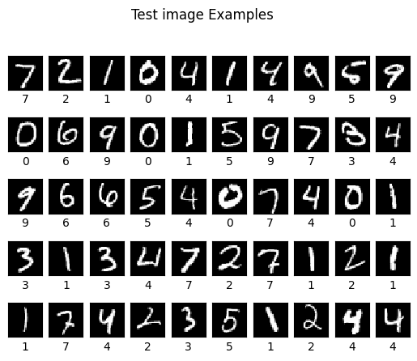

```python
### Bounus 1: show the first 40 images
### ALways a good idea to validate that the data appears as you expect
###
### for sci-kit learn the images are represented as vectors of 784 elements
### currently scaled from 0 to 1

for i in range(50):
    l1_plot = plt.subplot(5, 10, i + 1)
    l1_plot.imshow(255 * X_test[i].reshape(28, 28), interpolation='nearest',
                   cmap=plt.cm.gray)
    l1_plot.set_xticks(())
    l1_plot.set_yticks(())
    #l1_plot.set_xlabel('Class %s' % y_test[i].decode())
    l1_plot.set_xlabel('%s' % str(y_test[i]))
plt.suptitle('Test image Examples')
plt.show()
```

```python
## Data standardization
## by the mean and standared deviation of the training set
scaler = StandardScaler()
X_train = scaler.fit_transform(X_train)
X_test = scaler.transform(X_test)
```

```python
#train and test classifier
# Turn up tolerance for faster convergence
clf = LogisticRegression(C=50. / 1000,
                         multi_class='multinomial',
                         penalty='l1', solver='saga', tol=0.1)
# Train the classifier
clf.fit(X_train, y_train)

#Evaluate the classifier
sparsity = np.mean(clf.coef_ == 0) * 100
score = clf.score(X_test, y_test)
# print('Best C % .4f' % clf.C_)
print("Sparsity with L1 penalty: %.2f%%" % sparsity)
print("Test score with L1 penalty: %.4f" % score)
```

```
Sparsity with L1 penalty: 16.01%
Test score with L1 penalty: 0.8915
```

```python
""" Custom datatset loader
    based on https://github.com/utkuozbulak/pytorch-custom-dataset-examples
"""
import pandas as pd
import imageio

class SimpleDataset():
    def __init__(self, data_path, csv_name, transform = None ):
        """
        Args:
            data_path (string): path to the folder where images and csv files are located
            csv_name (string): name of the csv lablel file
            transform: pytorch transforms for transforms and tensor conversion
        """
        # Set path
        self.data_path = data_path
        # Read the csv file
        self.data_info = pd.read_csv(data_path + csv_name, header=None)
        # First column contains the image paths
        self.image_arr = np.asarray(self.data_info.iloc[:, 0])
        # Second column is the labels
        self.label_arr = np.asarray(self.data_info.loc[:, 1])
        # Calculate len
        self.data_len = len(self.data_info.index)

    def __getitem__(self, index):
        # Get image name from the pandas df
        single_image_name = self.image_arr[index]
        # Open image
        img_as_img = imageio.imread(self.data_path + single_image_name)

        # Get label(class) of the image based on the cropped pandas column
        single_image_label = self.label_arr[index]

        return (img_as_img, single_image_label)

    def __len__(self):
        return self.data_len
```

```python
# My dataset: idata
mydata = SimpleDataset( "./idata/", "labels.csv")

#splitting into images and labels
X = []
y = []
for i in range(len(mydata)):
    X.append(mydata[i][0])
    y.append((mydata[i][1]))

#converting into numpy arrays to enable easy reshaping and other array operations

X = np.asarray(X)
print("Shape of the input image", X.shape)
y= np.asarray(y)
```

```
Shape of the input image (60, 28, 28)
```

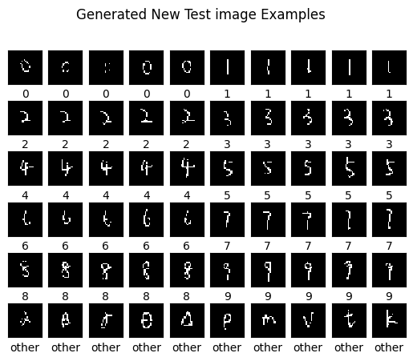

```python
import warnings
warnings.filterwarnings('ignore')
for i in range(60):
    l1_plot = plt.subplot(6, 10, i + 1)
    l1_plot.imshow(X[i], interpolation='nearest',
                   cmap=plt.cm.gray)
    l1_plot.set_xticks(())
    l1_plot.set_yticks(())
    l1_plot.set_xlabel('%s' % (y[i]))
plt.suptitle('Generated New Test image Examples')
plt.show()
```

```python
#reshaping the array into flattened 784 array as an input for prediciton by the logistic regression classifier
X = X.reshape(X.shape[0], 784)
X = X / 255.
#data standardiation with the training set statistics is required for this clasifier
X = scaler.transform(X)

y_pred = clf.predict(X)

score = clf.score(X, y)

print("Test score with L1 penalty: %.4f" % score)
print("y_predicted_values", y_pred)
print("y_labels", y)
```

```
Test score with L1 penalty: 0.1000
y_predicted_values ['4' '1' '1' '4' '4' '1' '1' '1' '1' '1' '1' '1' '1' '1' '1' '1' '1' '1'
 '1' '1' '1' '4' '1' '1' '1' '4' '1' '1' '1' '1' '1' '4' '1' '1' '1' '1'
 '1' '1' '1' '1' '1' '1' '1' '1' '1' '1' '1' '1' '1' '1' '1' '1' '1' '4'
 '4' '1' '4' '4' '1' '1']
y_labels ['0' '0' '0' '0' '0' '1' '1' '1' '1' '1' '2' '2' '2' '2' '2' '3' '3' '3'
 '3' '3' '4' '4' '4' '4' '4' '5' '5' '5' '5' '5' '6' '6' '6' '6' '6' '7'
 '7' '7' '7' '7' '8' '8' '8' '8' '8' '9' '9' '9' '9' '9' 'other' 'other'
 'other' 'other' 'other' 'other' 'other' 'other' 'other' 'other']
```

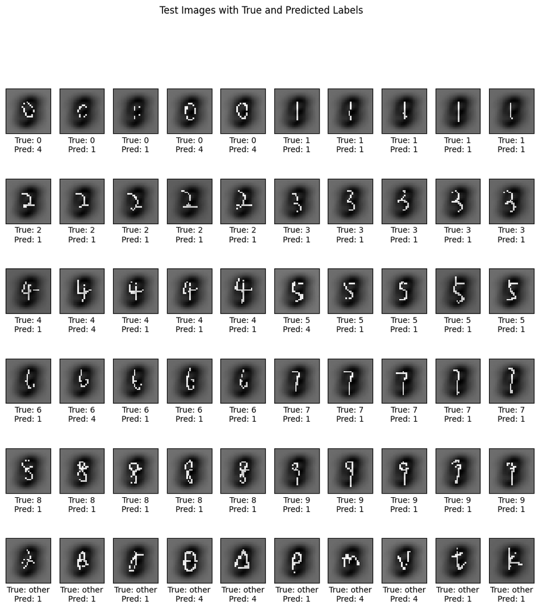

```python
import matplotlib.pyplot as plt

# Make predictions on the test set
y_pred = clf.predict(X)

# Plot the first 60 test images with true and predicted labels
plt.figure(figsize=(12, 12))
for i in range(60):
    # Plot each image
    plt.subplot(6, 10, i + 1)
    plt.imshow(X[i].reshape(28, 28), interpolation='nearest', cmap=plt.cm.gray)  # Reshape back to 28x28
    plt.xticks([])  # Hide x-axis ticks
    plt.yticks([])  # Hide y-axis ticks
    # Display the true label and predicted label
    plt.xlabel(f"True: {y[i]}\nPred: {y_pred[i]}")
plt.suptitle('Test Images with True and Predicted Labels')
plt.show()
```

```python
# My dataset: idata2
mydata = SimpleDataset( "./idata2/", "labels.csv")

#splitting into images and labels
X = []
y = []
for i in range(len(mydata)):
    X.append(mydata[i][0])
    y.append((mydata[i][1]))

#converting into numpy arrays to enable easy reshaping and other array operations

X = np.asarray(X)
print("Shape of the input image", X.shape)
y= np.asarray(y)
```

```
Shape of the input image (60, 28, 28)
```

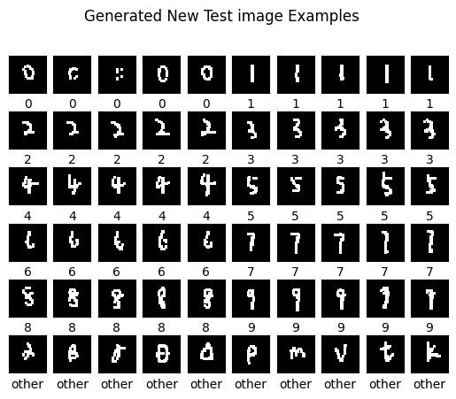

```python
import warnings
warnings.filterwarnings('ignore')
for i in range(60):
    l1_plot = plt.subplot(6, 10, i + 1)
    l1_plot.imshow(X[i], interpolation='nearest',
                   cmap=plt.cm.gray)
    l1_plot.set_xticks(())
    l1_plot.set_yticks(())
    l1_plot.set_xlabel('%s' % (y[i]))
plt.suptitle('Generated New Test image Examples')
plt.show()
```

```python
#reshaping the array into flattened 784 array as an input for prediciton by the logistic regression classifier
X = X.reshape(X.shape[0], 784)
X = X / 255.
#data standardiation with the training set statistics is required for this clasifier
X = scaler.transform(X)

y_pred = clf.predict(X)

score = clf.score(X, y)

print("Test score with L1 penalty: %.4f" % score)
print("y_predicted_values", y_pred)
print("y_labels", y)
```

```
Test score with L1 penalty: 0.0833
y_predicted_values ['1' '1' '1' '1' '1' '1' '1' '1' '1' '1' '1' '1' '1' '1' '1' '1' '1' '1'
 '1' '1' '1' '1' '1' '1' '1' '1' '1' '1' '1' '1' '1' '1' '1' '1' '1' '1'
 '1' '1' '1' '1' '1' '1' '1' '1' '1' '1' '1' '1' '1' '1' '1' '1' '1' '1'
 '1' '1' '1' '1' '1' '1']
y_labels ['0' '0' '0' '0' '0' '1' '1' '1' '1' '1' '2' '2' '2' '2' '2' '3' '3' '3'
 '3' '3' '4' '4' '4' '4' '4' '5' '5' '5' '5' '5' '6' '6' '6' '6' '6' '7'
 '7' '7' '7' '7' '8' '8' '8' '8' '8' '9' '9' '9' '9' '9' 'other' 'other'
 'other' 'other' 'other' 'other' 'other' 'other' 'other' 'other']
```

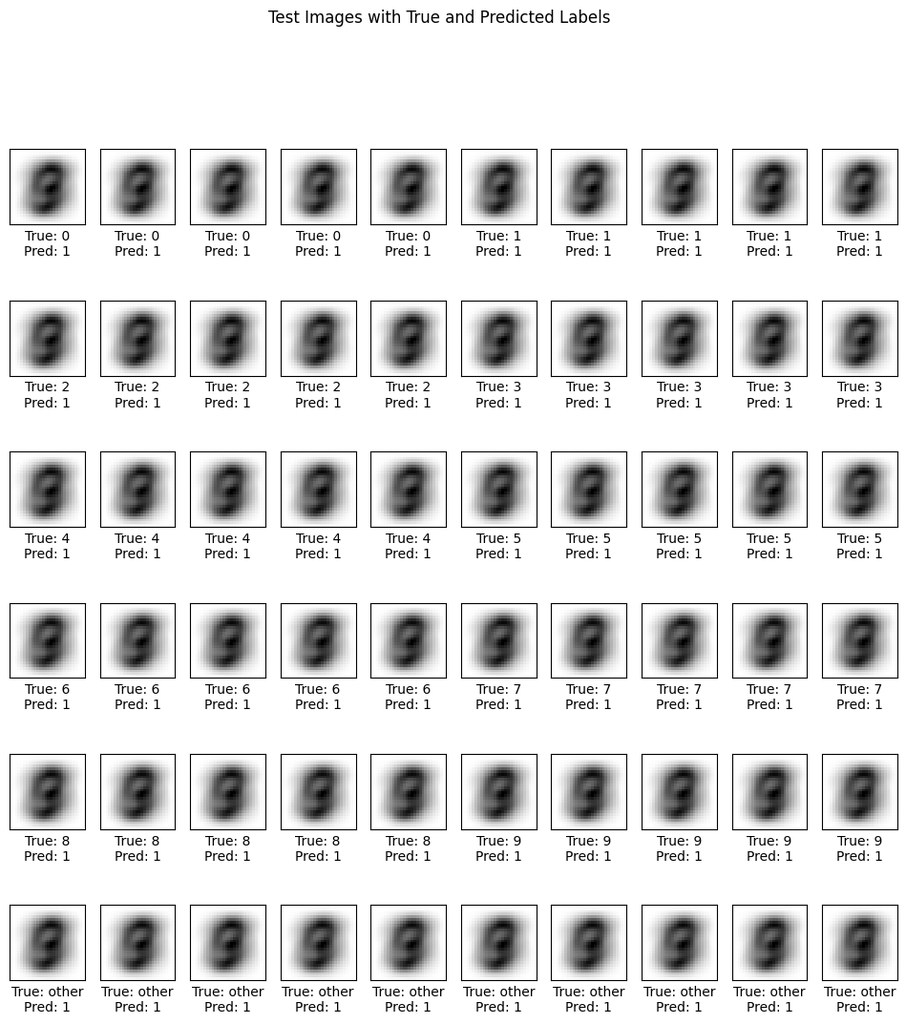

```python
import matplotlib.pyplot as plt

# Make predictions on the test set
y_pred = clf.predict(X)

# Plot the first 60 test images with true and predicted labels
plt.figure(figsize=(12, 12))
for i in range(60):
    # Plot each image
    plt.subplot(6, 10, i + 1)
    plt.imshow(X[i].reshape(28, 28), interpolation='nearest', cmap=plt.cm.gray)  # Reshape back to 28x28
    plt.xticks([])  # Hide x-axis ticks
    plt.yticks([])  # Hide y-axis ticks
    # Display the true label and predicted label
    plt.xlabel(f"True: {y[i]}\nPred: {y_pred[i]}")
plt.suptitle('Test Images with True and Predicted Labels')
plt.show()
```

Discussion: For idata dataset, the accuracy is low, and the main reason is that I wrote all numbers in a very thin region. However, the numbers in training samples in the MNIST dataset take up more spaces (they are wider on the paper). Thus, a lot of predictions are 1 and 4. For idata2 dataset, it is very weird that all the output look the same and all predicted values are 1. All my input look good, as they are thicker than before.